# Módulo 10 — Utilización variable, costos de ajuste del capital y q de Tobin

**Curso complementario · puremacro · mazo Slides07 (bloque B1) — mecanismos y economía abierta**

El mazo B1 cubre las semanas 13–14; **esta lección es la mitad de la semana 14** (capital y choques: utilización, costos de ajuste, $q$ de Tobin, choques específicos a la inversión). La otra mitad —economía pequeña y abierta— va en la lección `10b`.

### Objetivos de aprendizaje

Al terminar esta lección podrás:

1. Explicar la **utilización variable del capital**, por qué es **procíclica** y cómo sesga al residuo de Solow.
2. Motivar los **costos de ajuste** de la inversión y derivar la intuición de la **q de Tobin** (marginal vs. promedio, Hayashi 1982).
3. Estimar con **proyecciones locales (LP-HAC)** la respuesta de la inversión ante un choque a $\Delta\log q$, y ver por qué la q agregada explica **poco**.
4. Interpretar los **choques específicos a la inversión** vía el precio relativo de los bienes de inversión.

Todo corre en Python puro sobre tu **instalación local** de `puremacro` (`pip install puremacro`), con los datos congelados del *bundle*: sin conexión y sin costo.

> **Dónde se evalúa esto.** La extensión del RBC con **utilización variable** $u_t$ y **costos de ajuste** $\phi$ entra en los **dos** finales: la **derivación analítica** en el **Examen Final Teórico** —Sección 1 (CPO de utilización, Euler con $q$ de Tobin) y Sección 3 (lectura de la salida empírica de $q$), que juntas son el **60%** de ese examen— y su **implementación** en la **Parte D del Examen Final Computacional**. Lo que **no** es es material de la **Tarea 2**, que se queda con el RBC canónico del mazo A4, sin $u_t$ y sin $\phi$. Esta lección prepara para ambas cosas.

## 1. Utilización variable del capital

En el modelo neoclásico básico el capital $K_t$ es **fijo dentro del periodo**, así que los *servicios de capital* son proporcionales a $K_t$. En la realidad la empresa decide también **cuán intensamente** usa esa maquinaria: la tasa de utilización $u_t$. Los servicios efectivos son $u_t\,K_t$, no $K_t$.

- Correr la planta más fuerte (más turnos, menos tiempo muerto) **eleva la producción** sin instalar capital nuevo.
- El costo: la utilización acelera la **depreciación**, $\delta(u_t)$ con $\delta'>0$. Ese margen relaciona $u_t$ con las condiciones de demanda.

### ¿Por qué importa? El residuo de Solow

La utilización es **procíclica**: en auges las empresas usan el capital instalado más intensamente. Si medimos la PTF (residuo de Solow) usando $K_t$ en vez de $u_t K_t$, atribuimos a "tecnología" lo que en realidad es **mayor utilización**. Resultado: el residuo de Solow medido **exagera** la ciclicidad de la PTF (Burnside–Eichenbaum–Rebelo; Basu–Kimball).

El mazo documenta este hecho con **datos observados**: la utilización de la capacidad de EUA (`TCU`, Reserva Federal) es fuertemente procíclica frente a la producción industrial (`INDPRO`). Esa serie **no viaja en el *bundle* offline** y el curso corre con la red cerrada, así que aquí la **simulamos** anclada al ciclo real del PIB (`GDPC1`) y la marcamos como simulada.

> **Qué prueba y qué no prueba lo que sigue.** La correlación que vas a ver es **positiva por construcción**: la fabricamos así. No es evidencia de nada — es una **ilustración** del mecanismo. La evidencia está en `TCU` (mazo B1) y en la PTF ajustada por utilización de Fernald. Tampoco calibramos la volatilidad relativa contra `TCU`: el número que se imprime abajo es el de la simulación, no un momento del dato.

```python
from puremacro.data import hp_filter

gdp = fred("GDPC1").dropna()
gdp = gdp[gdp.index >= START]
log_gdp = 100.0 * np.log(gdp.values)             # PIB real en log-puntos
gdp_cycle, _ = hp_filter(log_gdp)                 # (ciclo, tendencia)
gdp_cycle = np.asarray(gdp_cycle)

# SERIE SIMULADA (declarada): utilización procíclica alrededor de 80%, anclada al ciclo
# real del PIB más ruido idiosincrático. No es un dato observado.
rng = np.random.default_rng(20260721)
util_sim = 80.0 + 0.9 * gdp_cycle + 0.5 * rng.standard_normal(gdp_cycle.size)
util_cycle, _ = hp_filter(util_sim)
util_cycle = np.asarray(util_cycle)

corr_util = np.corrcoef(util_cycle, gdp_cycle)[0, 1]
print(f"corr(ciclo utilización SIMULADA, ciclo PIB) = {corr_util:.2f}  [por construcción]")
print(f"volatilidad relativa  sd(u)/sd(PIB)         = {util_cycle.std()/gdp_cycle.std():.2f}"
      "  [de la simulación, NO calibrada contra TCU]")
assert corr_util > 0.5                            # procíclica por construcción
```

```
corr(ciclo utilización SIMULADA, ciclo PIB) = 0.91  [por construcción]
volatilidad relativa  sd(u)/sd(PIB)         = 0.88  [de la simulación, NO calibrada contra TCU]
```

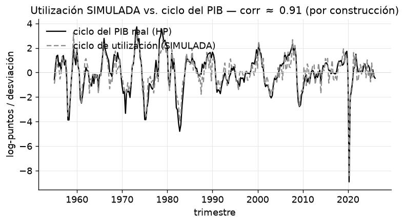

```python
cols = _nbstyle.palette(2)
q_idx = gdp.index
fig, ax = plt.subplots(figsize=(7.4, 3.6))
ax.plot(q_idx, gdp_cycle, color=cols[0], lw=1.4, label="ciclo del PIB real (HP)")
ax.plot(q_idx, util_cycle, color="0.55", lw=1.4, ls=(0, (4, 2)),
        label="ciclo de utilización (SIMULADA)")
ax.axhline(0, color="0.85", lw=0.6)
ax.set_xlabel("trimestre"); ax.set_ylabel("log-puntos / desviación")
ax.set_title("Utilización SIMULADA vs. ciclo del PIB — "
             f"corr $\\approx$ {corr_util:.2f} (por construcción)")
ax.legend(loc="upper left", ncol=1)
plt.show()
```

## 2. Costos de ajuste y la q de Tobin

Sin costos de ajuste, la inversión es un problema *bang-bang*: la empresa saltaría su capital al punto donde el producto marginal iguala el costo de uso — una regla de esquina, sin dinámica interesante. La **q de Tobin** necesita **costos de ajuste convexos** $\Phi(I_t/K_t)$: instalar rápido es costoso, así que la inversión se suaviza.

### q marginal y q promedio

Con costos de ajuste convexos, la condición de primer orden de la empresa dice que la inversión es **creciente en la q marginal**: $$ q^{m}_t = \frac{\text{valor sombra de una unidad de capital instalada}}{\text{precio del capital}}. $$ El problema: $q^m$ **no se observa**. Hayashi (1982) mostró que, bajo **rendimientos constantes a escala** y competencia perfecta, la q marginal **iguala** a la q promedio: $$ q^{m}_t = q^{a}_t = \frac{\text{valor de mercado de la empresa}}{\text{costo de reposición del capital}}, $$ y esta última **sí** se observa. Es la q de Tobin.

Proxy agregado (sector corporativo no financiero, *Flow of Funds*): $$ q_t = \frac{\text{valor de mercado del capital accionario (NCBEILQ027S)}}{\text{patrimonio neto a valor de mercado (TNWMVBSNNCB)}}. $$ Es la conocida "Q ratio" de Smithers–Wright: $q>1$ = el mercado valora a las empresas por encima del costo de reponer su capital → incentivo a invertir.

> **Ficha de medición (y el control de unidades del mazo).** *Fuente/serie:* Fed Z.1 vía FRED — `NCBEILQ027S` (acciones corporativas, pasivo) sobre `TNWMVBSNNCB` (patrimonio neto a valor de mercado), empresas **no financieras**; inversión `GPDIC1` (real, encadenada). *Muestra:* 1955Q1 en adelante — antes de **1952** la Z.1 sólo publica el cuarto trimestre, así que la serie no es trimestral contigua. *Unidades:* las **dos** series vienen en **millones de dólares**, de modo que el cociente es **adimensional y del orden de la unidad**. Si te sale $q\approx 0.001$ dividiste sólo el numerador entre 1000: comprueba la ficha de FRED, no el nombre de la serie. *Transformación:* $q$ en nivel para la gráfica, $100\,\Delta\log q$ como impulso. *Advertencia conceptual:* el denominador es el patrimonio neto **a valor de mercado**, que el curso usa como aproximación al costo de reposición; omite el capital **intangible** (de ahí la *total q* de Peters–Taylor que discute el mazo).

```python
equity = fred("NCBEILQ027S")     # valor de mercado del capital accionario (pasivo)
networth = fred("TNWMVBSNNCB")   # patrimonio neto a valor de mercado (Net Worth Market Value)
inv = fred("GPDIC1")             # inversión privada bruta real

# Ambas en MILLONES de dólares: el cociente sale adimensional. NO dividir una sola.
q_ratio = (equity / networth).rename("q")

df = pd.concat([q_ratio, inv.rename("inv")], axis=1).dropna()
df = df[df.index >= START]
df["log_inv"] = 100.0 * np.log(df["inv"])        # inversión en log-puntos (respuesta en %)
df["dlog_q"] = 100.0 * np.log(df["q"]).diff()    # choque: variación % de la q
print(f"q de Tobin: min = {df['q'].min():.2f}, max = {df['q'].max():.2f}, "
      f"último = {df['q'].iloc[-1]:.2f}   (n = {len(df)} trimestres)")
```

```
q de Tobin: min = 0.29, max = 1.94, último = 1.82   (n = 285 trimestres)
```

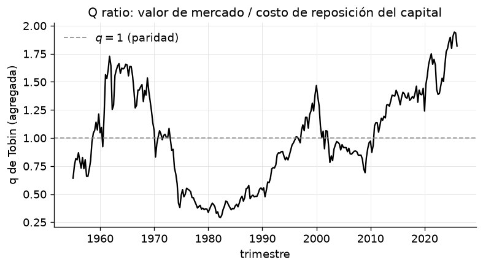

```python
fig, ax = plt.subplots(figsize=(7.4, 3.6))
ax.plot(df.index, df["q"].values, color=cols[0], lw=1.4)
ax.axhline(1.0, color="0.55", lw=1.0, ls=(0, (4, 2)), label="$q = 1$ (paridad)")
ax.set_xlabel("trimestre"); ax.set_ylabel("q de Tobin (agregada)")
ax.set_title("Q ratio: valor de mercado / costo de reposición del capital")
ax.legend(loc="upper left")
plt.show()
```

### LP-HAC: respuesta de la inversión a un choque de q

Estimamos con **proyecciones locales** de Jordà (2005), con errores estándar HAC (Newey–West, ancho de banda $h+1$ según Plagborg-Møller–Wolf 2021), la respuesta acumulada del (log) de la inversión ante un choque de $\Delta\log q$: $$ \text{inv}_{t+h} - \text{inv}_{t-1} = \alpha_h + \beta_h\,\Delta\log q_t + \sum_l \gamma_l z_{t-l} + \varepsilon_{t,h}. $$

> **Dos trampas de especificación.** (i) `lp_hac` **ya acumula**: construye internamente $y_{t+h}-y_{t-1}$, así que se le pasa el **nivel** de $100\log(\text{inv})$, **no** su diferencia; si le pasas $\Delta\log(\text{inv})$ estimas la respuesta del *crecimiento*, que es otra cosa. (ii) Usamos `n_lags=4` y el nivel de `GPDIC1`, que es exactamente la especificación de la figura del mazo (`fig_q_tobin_lp`), para que lo que veas aquí y lo que veas proyectado en clase sean lo mismo. El resultado es robusto: con `n_lags=2`, o arrancando la muestra en 1952 en vez de 1955, el pico sigue en $h=5$ con $\beta$ entre $0.36$ y $0.39$.

```python
from puremacro.lp import lp_hac

irf = lp_hac(df.reset_index(drop=True), y="log_inv", x="dlog_q",
             horizons=range(0, 13), n_lags=4)   # misma spec que la figura del mazo
print(irf[["h", "beta", "se", "t", "lo", "hi"]].round(3).to_string(index=False))

peak = irf.loc[irf["beta"].idxmax()]
print(f"\npico en h = {int(peak['h'])} trimestres: beta = {peak['beta']:.3f} "
      f"(t = {peak['t']:.2f})")
assert peak["beta"] > 0 and peak["lo"] > 0        # respuesta positiva y significativa
```

```
 h   beta    se      t     lo    hi
 0 -0.039 0.031 -1.235 -0.091 0.013
 1  0.119 0.045  2.626  0.044 0.193
 2  0.254 0.050  5.100  0.172 0.336
 3  0.366 0.060  6.051  0.266 0.465
 4  0.373 0.064  5.853  0.268 0.478
 5  0.385 0.077  5.034  0.259 0.511
 6  0.372 0.077  4.814  0.245 0.499
 7  0.297 0.073  4.063  0.177 0.417
 8  0.299 0.080  3.743  0.167 0.430
 9  0.277 0.069  3.994  0.163 0.391
10  0.266 0.071  3.733  0.149 0.383
11  0.246 0.072  3.408  0.127 0.365
12  0.216 0.077  2.799  0.089 0.342

pico en h = 5 trimestres: beta = 0.385 (t = 5.03)
```

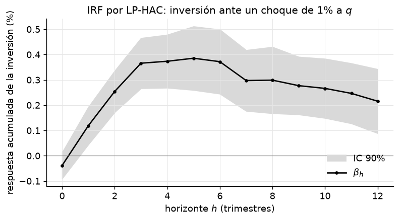

```python
fig, ax = plt.subplots(figsize=(7.4, 3.6))
h = irf["h"].values
ax.fill_between(h, irf["lo"].values, irf["hi"].values, color="0.85",
                label="IC 90%")
ax.plot(h, irf["beta"].values, color=cols[0], lw=1.6, marker="o", ms=3,
        label=r"$\beta_h$")
ax.axhline(0, color="0.55", lw=0.8)
ax.set_xlabel("horizonte $h$ (trimestres)")
ax.set_ylabel("respuesta acumulada de la inversión (%)")
ax.set_title(r"IRF por LP-HAC: inversión ante un choque de 1% a $q$")
ax.legend(loc="lower right")
plt.show()
```

### La q agregada explica *poco* la inversión

La respuesta dinámica es positiva y significativa, pero la q **contemporánea** explica una fracción minúscula de la varianza del crecimiento de la inversión: la correlación simple es **negativa y prácticamente cero**, y el $R^2$ implícito no llega al 1%. Ese contraste —dinámica clara, $R^2$ diminuto— es el hecho estilizado central de esta literatura y el **fracaso empírico clásico** de la teoría q: en la teoría, $q$ debería ser un **estadístico suficiente** para la inversión.

```python
dlog_inv = df["log_inv"].diff().iloc[1:].values
dlog_q = df["dlog_q"].iloc[1:].values
rho = np.corrcoef(dlog_inv, dlog_q)[0, 1]
r2_contemp = rho ** 2
print(f"corr(Δ log inv, Δ log q)         = {rho:.3f}   (¡el signo ni siquiera es positivo!)")
print(f"R^2 contemporáneo                = {r2_contemp:.3f}")
assert r2_contemp < 0.05                          # la q agregada explica casi nada
```

```
corr(Δ log inv, Δ log q)         = -0.089   (¡el signo ni siquiera es positivo!)
R^2 contemporáneo                = 0.008
```

## 3. Choques específicos a la inversión

El **precio relativo de los bienes de inversión** (respecto al consumo) ha caído de forma secular: producir una unidad de capital cuesta cada vez menos en términos de consumo. Esa caída es **cambio tecnológico específico a la inversión** (Greenwood–Hercowitz–Krusell 1997). Aquí construimos el **impulso ingenuo** $\text{IST}_t = -\Delta\log(p^{I}_t)$: una caída del precio relativo actúa como una mejora en la eficiencia de transformar producto en capital.

> **`PIRIC` no es `PERIC`.** La serie del *bundle*, `PIRIC`, es el precio de la **inversión total** relativo al consumo. GHK (1997), Fisher (2006) y Justiniano–Primiceri–Tambalotti (2010) usan el precio del **equipo**, `PERIC`, que no viaja offline y exige red. No son intercambiables: el equipo cae un factor $\approx41$ desde 1947 ($\approx4.8\%$ anual), mientras la inversión total apenas cae un factor $\approx5$ ($\approx2.2\%$ anual), porque el agregado arrastra estructuras y vivienda, que casi no se abaratan. La caída secular que vas a ver es real, pero es **la del agregado**, no la cifra que citan esos artículos.

```python
pinv = fred("PIRIC").dropna()                     # precio de la inversión relativo al consumo
pinv = pinv[pinv.index >= START]
ist = (-100.0 * np.log(pinv).diff()).dropna()     # choque IST (variación %, signo positivo = mejora)
print(f"precio relativo de la inversión: {pinv.iloc[0]:.2f} (1955) -> {pinv.iloc[-1]:.2f} "
      f"({pinv.index[-1].year})")
print(f"caída acumulada = {100.0*np.log(pinv.iloc[0]/pinv.iloc[-1]):.0f} log-puntos")
print(f"IST promedio (anualizado) = {ist.mean()*4:.2f} pp/año,  sd trimestral = {ist.std():.2f}")
```

```
precio relativo de la inversión: 4.27 (1955) -> 0.88 (2024)
caída acumulada = 158 log-puntos
IST promedio (anualizado) = 2.27 pp/año,  sd trimestral = 0.56
```

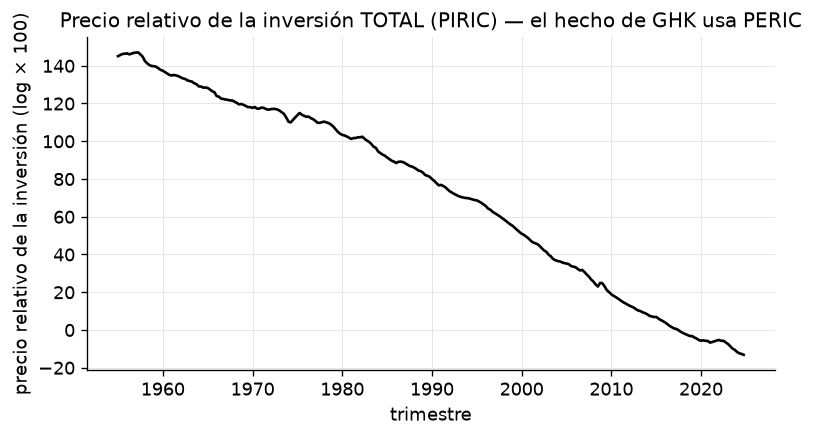

```python
fig, ax = plt.subplots(figsize=(7.4, 3.6))
ax.plot(pinv.index, 100.0 * np.log(pinv.values), color=cols[0], lw=1.6)
ax.set_xlabel("trimestre")
ax.set_ylabel("precio relativo de la inversión (log $\\times$ 100)")
ax.set_title("Precio relativo de la inversión TOTAL (PIRIC) — el hecho de GHK usa PERIC")
plt.show()
```

### ¿Responde la inversión al "choque" IST? Lo que sale y lo que no

Repetimos la LP-HAC usando $-\Delta\log p^{I}$ como impulso. La teoría dice que un abaratamiento del capital debería elevar la inversión —el canal detrás de los choques a la "eficiencia marginal de la inversión" (Justiniano–Primiceri–Tambalotti 2010)—, así que esperamos $\beta_h>0$.

**Mira la tabla antes de creerte la teoría.** Los puntos estimados son positivos en los primeros horizontes, pero los errores estándar son enormes: la banda del 90% **contiene cero en todos los horizontes** y ningún $|t|$ llega a 1.5. Esta salida **no** establece que la inversión responda al choque IST. Tres razones, y las tres son la lección del ejercicio:

1. **No hay identificación.** $-\Delta\log p^{I}_t$ es una variable observada, no un choque estructural: el precio relativo se mueve también por demanda, márgenes y composición. El mazo identifica el choque IST **como es debido**, con Blanchard–Quah bivariado a la Fisher (2006) —el IST es el único con efecto permanente sobre el precio relativo del equipo—, no con la primera diferencia cruda.
2. **Serie equivocada para el hecho.** Usamos `PIRIC` (inversión total) porque `PERIC` (equipo) no viaja offline; el agregado diluye justo la variación que identifica el canal.
3. **Señal débil.** $sd(\text{IST})\approx0.6$ pp trimestrales sobre ~279 trimestres, y buena parte de esa variación es ruido de deflactores y revisiones: no hay potencia.

Que el punto estimado tenga el signo de la teoría es sugerente y nada más. Publicar "la inversión sube ante el choque IST" con esta tabla sería exactamente el error que este curso persigue.

```python
dfi = pd.concat([100.0 * np.log(inv).rename("log_inv"), ist.rename("ist")], axis=1).dropna()
dfi = dfi[dfi.index >= START]
irf_ist = lp_hac(dfi.reset_index(drop=True), y="log_inv", x="ist",
                 horizons=range(0, 13), n_lags=2)
print(irf_ist[["h", "beta", "se", "t", "lo", "hi"]].round(3).to_string(index=False))
peak_ist = irf_ist.loc[irf_ist["beta"].abs().idxmax()]
n_signif = int(((irf_ist["lo"] > 0) | (irf_ist["hi"] < 0)).sum())
print(f"\nrespuesta máxima en h = {int(peak_ist['h'])}: beta = {peak_ist['beta']:.3f} "
      f"(t = {peak_ist['t']:.2f})")
print(f"horizontes con banda del 90% que EXCLUYE cero: {n_signif} de {len(irf_ist)} "
      f"  ->  el signo es el de la teoría, la precisión no acompaña")
assert n_signif == 0        # ninguna banda excluye cero: el texto lo dice así
```

```
 h   beta    se      t     lo    hi
 0  0.918 0.636  1.444 -0.127 1.963
 1  1.026 1.194  0.860 -0.937 2.990
 2  2.010 1.529  1.315 -0.505 4.525
 3  2.107 1.644  1.281 -0.598 4.812
 4  1.468 1.564  0.939 -1.105 4.041
 5  0.750 1.869  0.401 -2.324 3.824
 6  0.284 1.885  0.151 -2.817 3.385
 7  0.079 1.926  0.041 -3.088 3.247
 8  0.139 1.775  0.078 -2.781 3.059
 9  0.169 1.549  0.109 -2.379 2.717
10  0.126 1.402  0.090 -2.181 2.433
11 -0.417 1.465 -0.284 -2.826 1.993
12 -0.427 1.401 -0.305 -2.732 1.878

respuesta máxima en h = 3: beta = 2.107 (t = 1.28)
horizontes con banda del 90% que EXCLUYE cero: 0 de 13   ->  el signo es el de la teoría, la precisión no acompaña
```

## 4. Ejercicios

1. **Utilización y Solow.** Si ignoramos $u_t$ (usamos $K_t$ en vez de $u_t K_t$), ¿en qué dirección sesgamos la ciclicidad del residuo de Solow? Razona con el **signo** de $\mathrm{corr}(u_t, \text{ciclo del PIB})$. Ojo con la trampa: la serie de arriba es **simulada** y ese signo lo pusiste tú al construirla. ¿En qué evidencia **observada** se apoya de verdad ese signo, según el mazo?
2. **q marginal vs. promedio.** Enumera dos supuestos de Hayashi (1982) que, al fallar, hacen que $q^{a}\neq q^{m}$. ¿Cómo afecta eso a la regresión de inversión sobre q?
3. **Costos de ajuste.** Si los costos de ajuste fueran **más** convexos, ¿la IRF de la inversión sería más rápida o más suave? Responde primero con la teoría. Después amplía `horizons` a `range(0, 21)` y describe la forma de la IRF **estimada** — y explica por qué esa figura, por sí sola, no mide $\phi$.
4. **q agregada y $R^2$.** Da tres razones por las que la q agregada explica tan poca varianza de la inversión trimestral (pista: error de medición, burbujas en el precio de las acciones, fricciones financieras, ajuste no convexo/*lumpy* a nivel planta).
5. **IST.** Estima la LP-HAC con `n_lags=4` para el impulso IST. ¿Cambia el pico? ¿Cambia en algo la **conclusión** sobre la significancia? ¿Qué haría falta para poder afirmar que la inversión responde al choque IST?

## 5. Explora con IA

Prueba esto con el tutor sin conexión (o cualquier asistente de IA):

- "En una frase, ¿por qué la q marginal puede diferir de la q promedio de Tobin?"
- "Si la q agregada explica muy poca varianza de la inversión, ¿qué fricciones podrían ser responsables?"

```python
print(tutor("En una frase, ¿por qué la q marginal de la inversión puede diferir de la "
            "q promedio de Tobin?"))
```

```
[tutor sin conexión] No hay ningún motor de LLM local disponible en esta instalación (el tutor es opcional). Puedes instalar uno con `pip install puremacro[local-llm]` más un modelo pequeño (por ejemplo vía Ollama o MLX), o bien usar las indicaciones de la sección «Explora con IA» de esta lección co…
(motivo: el motor local no está disponible)
```

**Resumen.** La **utilización variable** hace procíclicos los servicios de capital y sesga el residuo de Solow; los **costos de ajuste convexos** dan sentido a la inversión gradual y a la **q de Tobin** (marginal = promedio bajo Hayashi 1982). Con LP-HAC vimos que la inversión **sí** responde a $\Delta\log q$ —positiva y significativa, con pico cerca de $h=5$— pero que la q *agregada* explica **poca** varianza contemporánea (correlación simple casi nula, y de signo negativo): el hueco que motiva intangibles fuera del denominador, fricciones financieras, burbujas y ajuste *lumpy*. Del **precio relativo de la inversión** nos quedamos con el hecho secular —cae de forma sostenida— pero **no** con una IRF creíble: el impulso ingenuo $-\Delta\log p^{I}$ no está identificado y su LP no excluye cero en ningún horizonte. Ese contraste entre un hecho sólido y una estimación que no lo es también es parte de la lección.

**Siguiente módulo:** la lección **10b — economía pequeña y abierta** (`10b_economia_abierta_es`), que cierra la semana 14 del mazo Slides07 (B1) llevando estos mecanismos a una economía que puede prestar y pedir prestado al resto del mundo. Las **rigideces nominales** llegan después, en el bloque de las semanas 15–16 (lección **10c**), junto con las **fricciones de búsqueda y emparejamiento** del mercado laboral (lección **11**). Las fricciones *financieras* que el hueco del $R^2$ sugiere no tienen sesión propia en el programa; el hilo más cercano es la lección complementaria **23 — crecimiento en riesgo** (`23_growth_at_risk_es`), que mete las **condiciones financieras** (`NFCI`) en la distribución condicional del crecimiento.